# Art Project EDAV

Alexandra Sudomoeva, Elizabet Doliar, Serena Zhang, Basil Vetas

4/13/2018

# Introduction

# Data Description

## Overview

This dataset was provided by Arthena (https://arthena.com/). It was sourced from Sotheby’s historical auction data via the scraping of public web pages. The raw dataset includes 22711 rows of data. Each row represents an individual lot from an auction (a lot could be an individual painting, a sculpture, or sometimes even a collection of works). The raw dataset includes 25 columns of data. Each column represents a feature related to either that specific lot, the artist of the lot, or the auction where the lot was sold. Column definitions are listed below by category (Lot, Auction or Artist). For our analysis we also derive new columns from the original raw dataset. The details logic and thought process is described more in detail in the ‘Data Quality Analysis’.

## Column Definitions:

**Lot** lot_id: a unique id for each lot lot_title: the title of the lot. A lot can consist of multiple works (2-3 pieces of art in it). For our purposes we assume that 1 piece is 1 lot estimate_low: need to follow up if this is a starting price? estimate_high: estimated high price by the auction house hammer_price_bp: how much the lot was sold for at auction, plus buyers premium (a % fee). currency: currency denomination for the price estimates and hammer price (USD, EUR, GBP, HKD) nth_in_auction: order that the lot was presented in at auction lot_number: number assigned to a lot for the given auction, different than nth_in_auction  
condition: description of the condition of the lot (messy text field - not used) provenance: description of who owned the lot previously (messy text field - not used) literature: different publications that the lot was mentioned in (messy text field - not used) external_image_url: link to the image (not used)

**Auction** auction_house_id: unique id for each auction house (for this dataset, all 1 = Sotheby’s) auction_id: unique id for each auction auc_title: title of the auction number_of_lots: total number of lots in the auction location: location where the auction was held start_date: start date of the auction end_date: end date of the auction (same as start date for this dataset) auc_desc: description of the auction (messy text field - not used) sale_id: unique auction sale id assigned by Sotheby’s

**Artist** name: name of the artist birth_year: artist’s approximate birth year (messy text field - not used) death_year: artist’s approximate death year (messy text field - not used)

# Data Quality Analysis

### Overview

```r
art = read.csv("final_sothebys.csv", header=TRUE, na.strings=c("", NA))
#Save as a data frame
art_df <- as.data.frame(art)

#Dropping features with no interest (non-informative) in the analysis
drop <- c("X", "Unnamed..0", "provenance", "auction_house_id", "external_image_url", "literature", "end_date")
art_df <- art_df[, !(names(art_df) %in% drop)]

#Descriptive statistics
dim(art_df)
```

```
## [1] 22711    33
```

```r
typeof(art_df)
```

```
## [1] "list"
```

```r
str(art_df)
```

```
## 'data.frame':    22711 obs. of  33 variables:
##  $ lot_id             : int  364930 364927 364919 364917 364911 365083 365081 365080 365079 365078 ...
##  $ auction_id         : int  3 3 3 3 3 3 3 3 3 3 ...
##  $ lot_title          : Factor w/ 16730 levels "--------","... À TRAVERS SES LONGS CHEVEUX QUI LUI COUVRAIENT LA FIGURE, J'AI CRU RECONNAÎTRE AMMONARIA, LA TENTATION DE S"| __truncated__,..: 1892 5501 6221 12911 6404 2977 11456 9143 10836 435 ...
##  $ estimate_low       : num  35000 15000 25000 15000 3000 8000 5000 3000 2000 1500 ...
##  $ estimate_high      : num  45000 20000 35000 20000 5000 12000 7000 5000 3000 2500 ...
##  $ hammer_price_bp    : num  NA NA NA NA NA NA NA NA NA NA ...
##  $ currency           : Factor w/ 4 levels "EUR","GBP","HKD",..: 4 4 4 4 4 4 4 4 4 4 ...
##  $ nth_in_auction     : int  20 17 10 8 3 173 171 170 169 168 ...
##  $ lot_number         : int  20 17 10 8 3 174 172 171 170 169 ...
##  $ condition          : Factor w/ 18776 levels "- cup on foot: a bump on the rim, some tiny holes on foot, foot with some slight damage, otherwise in good cond"| __truncated__,..: NA 6588 NA NA NA NA NA NA NA NA ...
##  $ auc_title          : Factor w/ 110 levels "'1 in 11' Auction",..: 14 14 14 14 14 14 14 14 14 14 ...
##  $ number_of_lots     : int  173 173 173 173 173 173 173 173 173 173 ...
##  $ location           : Factor w/ 8 levels "AMSTERDAM","DOHA",..: 7 7 7 7 7 7 7 7 7 7 ...
##  $ start_date         : Factor w/ 234 levels "2006-03-31 15:15:23.000",..: 234 234 234 234 234 234 234 234 234 234 ...
```

[output cut: 19 more lines]

```r
#summary(art_df)
#head(art_df, n=5)
#tail(art_df, n=5)
```

### Column Definitions:

```r
# Note that "provenance", "auction_house_id", "external_image_url", "literature" and "end_date" were dropped
names(art_df)
```

```
##  [1] "lot_id"              "auction_id"          "lot_title"
##  [4] "estimate_low"        "estimate_high"       "hammer_price_bp"
##  [7] "currency"            "nth_in_auction"      "lot_number"
## [10] "condition"           "auc_title"           "number_of_lots"
## [13] "location"            "start_date"          "auc_desc"
## [16] "sale_id"             "artist_id"           "name"
## [19] "birth_year"          "death_year"          "auc_date"
## [22] "auc_year"            "auc_month"           "auc_season"
## [25] "is_untitled"         "auc_order"           "percent_in_auction"
## [28] "estimate_avg"        "hammer_price_bp_usd" "estimate_low_usd"
## [31] "estimate_high_usd"   "estimate_avg_usd"    "price_range"
```

**Lot**  
lot_id: a unique id for each lot.  
lot_title: the title of the lot. A lot can sometimes consist of multiple pieces of art. We assume that 1 piece is 1 lot since that is most common.  
estimate_low: the low-end auction price estimate for a lot, given by Sothebys.  
estimate_high: the high-end auction price estimate for a lot, given by Sothebys.  
hammer_price_bp: how much the lot was sold for at auction, plus buyers premium (a percentage fee taken by Sothebys and paid by the buyer).  
currency: currency denomination for the price estimates and hammer price (limited to USD, EUR, GBP, HKD).  
nth_in_auction: the order that the lot was presented in at auction.  
lot_number: a number assigned to a lot for the given auction, different than nth_in_auction.  
condition: description of the condition of the lot (messy text field - not used for our analysis).  
provenance: description of who owned the lot previously (messy text field - not used for our analysis).  
literature: different publications that the lot was mentioned in (messy text field - not used for our analysis).  
external_image_url: link to the image (not used for our analysis).

**Auction**  
auction_house_id: unique id for each auction house (for this dataset, all 1 since we are only using Sothebys data).  
auction_id: unique id for each auction.  
auc_title: title of the auction.  
number_of_lots: total number of lots in the auction.  
location: location where the auction was held.  
start_date: start date of the auction.  
end_date: end date of the auction (same as start date for this dataset).  
auc_desc: description of the auction (messy text field - not used for our analysis).  
sale_id: unique auction sale id assigned by Sothebys.

**Artist**  
artist_id: unique id for each artist.  
name: name of the artist.  
birth_year: artist’s approximate birth year (messy text field - not used for our analysis).  
death_year: artist’s approximate death year (messy text field - not used for our analysis).

**Derived**  
estimate_avg: the average between estimate_low and estimate_high.  
is_untitled: an indicator variable whether the name of the lot is “untitled” (in some language).  
auc_year: the year of the auction (YYYY format).  
auc_month: the month of the auction (as integers 1-12).  
auc_season: the season of the auction (as integers 1-4).  
auc_date: the date of the auction.  
auc_order: the order in the auction by quantiles (as integers 1-10).  
percent_in_auction: the percentage through an auction that a lot was shown (nth_in_auction divided by number_of_lots).  
hammer_price_bp_usd: hammer_price_bp converted to usd.  
estimate_high_usd: estimate_high converted to usd.  
estimate_low_usd: estimate_low converted to usd.  
estimate_avg_usd: estimate_avg converted to usd.  
price_range: factor of bucketed hammer price ranges in usd.

```r
# data types
sapply(art_df, class)
```

```
##              lot_id          auction_id           lot_title
##           "integer"           "integer"            "factor"
##        estimate_low       estimate_high     hammer_price_bp
##           "numeric"           "numeric"           "numeric"
##            currency      nth_in_auction          lot_number
##            "factor"           "integer"           "integer"
##           condition           auc_title      number_of_lots
##            "factor"            "factor"           "integer"
##            location          start_date            auc_desc
##            "factor"            "factor"            "factor"
##             sale_id           artist_id                name
##            "factor"           "integer"            "factor"
##          birth_year          death_year            auc_date
##           "numeric"            "factor"            "factor"
##            auc_year           auc_month          auc_season
##           "integer"           "integer"           "integer"
##         is_untitled           auc_order  percent_in_auction
##           "integer"           "integer"           "numeric"
##        estimate_avg hammer_price_bp_usd    estimate_low_usd
##           "numeric"           "numeric"           "numeric"
##   estimate_high_usd    estimate_avg_usd         price_range
##           "numeric"           "numeric"            "factor"
```

# Data Quality Analysis

## Preprocessing

In this part of the project, we will be exploring the quality of the data provided for the auction data. Before analyzing the overall quality, a simple preprocessing has been conducted in Python that included the following steps:

1. Added columns for normalized date (whole), year, month, and season.
2. ‘Start Date’ and ‘End Date’ are always the same within the dataset. Therefore, we decided to only user ‘Start Date’ for the time when the auction occured.
3. The “Title” column accepted a varity of title across different languages. We added a new column to show whether the piece is “untitles” while checking for the top 5 most common languages used: Italian, Dutch, English, French, Spanish, German.
4. Created a new column that would break the order of the auction into 10 tiles and group all pieces into those tiles by auction id
5. Added ‘Average Estimate’ column to reflect the aevrage price estimation between the high and the low
6. Converted all currency to USD to be able to compare pieces sold across different locations. We matched the exchange rate at the time of the sell to properly convert all transactions.

## Data Quality Exploration

```r
art = read.csv("final_sothebys.csv", header=TRUE, na.strings=c("", NA))
#Save as a data frame
art_df <- as.data.frame(art)
#Dropping features with no interest (non-informative) in the analysis
drop <- c("X", "Unnamed..0", "provenance", "auction_house_id", "external_image_url", "literature")
art_df <- art_df[, !(names(art_df) %in% drop)]
```

Let us start by looking at all the missing values and if there are any general patterns. Since we are dealing with a large amount of rows, we will reduce repeated patters to one row using the visna function.

```r
#install.packages("extracat")
library(extracat)
visna(art_df, sort= "b")
```

[figure not shown]

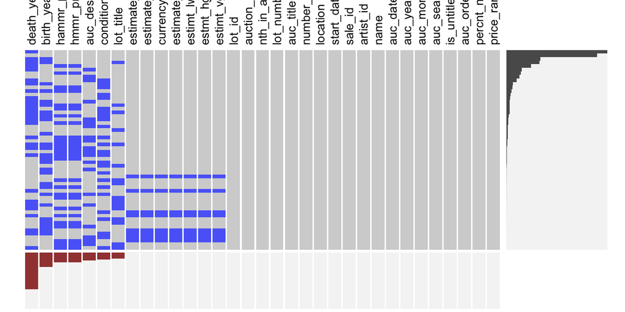

Looking at the output above, we can conclude that the overall state of the dataset is relatively good. The second most common pattern has no missing values while the two most “problematic” features appear to be death_year and birth_year.

One important observation we will need to be careful about during further analysis is a relatively significant amount of missing values under hammer_price_bp feature. We have explored qualitative reasons behind the missing values in that category with the provider of the data. After careful observation, we found out that the missing values are actually driven by two locations that migt have less strict regulations around data governance (Doha and Hong Kong). This observation is outlined in the graph below.

```r
#install.packages("viridis")
library(viridis)
art_location <- art_df %>% gather(attribute, value, -location) %>% mutate(missing = ifelse(is.na(value), "yes", "no"))
ggplot(art_location, aes(x = location, y = attribute, fill = missing)) +
  geom_tile(color = "white") +
  ggtitle("Missing Values by Location") +
  xlab("Location") + ylab("Feature Name") +
  scale_fill_viridis(discrete=TRUE) +
  theme_bw()
```

[figure not shown]

This map allows us to see that some features’ missing values like hammer_price_bp, condition, and auc_desc are actually only missing in certain location (typically in pairs of two). Therefore, we can speculate that this data is MAR (missing at random) depending on a location feature.

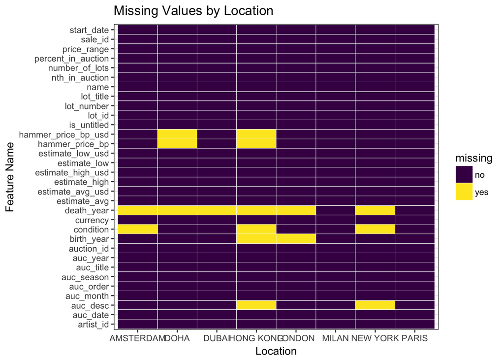

Indeed, when looking at the table below, the overall percentage of missing values across difeerent locations varies quite significantly. Hong Kong is the top location with most missing values (8% of total).

```r
art_location <- art_df %>% gather(attribute, value, -location)
percent_missing <- art_location %>% group_by(location) %>%
  summarise(num_na = sum(is.na(value)), total = n()) %>%
  mutate(percent_na = num_na/total)%>%
  arrange(-percent_na)
percent_missing
```

```
## # A tibble: 8 x 4
##   location  num_na  total percent_na
##   <fct>      <int>  <int>      <dbl>
## 1 HONG KONG   1118  14656     0.0763
## 2 AMSTERDAM   5231  70944     0.0737
## 3 PARIS       4758  81376     0.0585
## 4 MILAN       2323  44192     0.0526
## 5 NEW YORK   14676 309568     0.0474
## 6 DOHA          98   2144     0.0457
## 7 DUBAI         76   1728     0.0440
## 8 LONDON      8524 202144     0.0422
```

This leads to a logical question. Are there any other variables that could explain the missing data? Therefore, we also looked at simular graphs while grouping by year and month.

```r
#install.packages("viridis")
#library(viridis)
art_year <- art_df %>% gather(attribute, value, -auc_year) %>% mutate(missing = ifelse(is.na(value), "yes", "no"))
year <- ggplot(art_year, aes(x = factor(auc_year), y = attribute, fill = missing)) +
  geom_tile(color = "white") +
  ggtitle("Missing Values by Year") +
  xlab("year") + ylab("Feature Name") +
  scale_fill_viridis(discrete=TRUE) +
  theme_bw()
art_month <- art_df %>% gather(attribute, value, -auc_month) %>% mutate(missing = ifelse(is.na(value), "yes", "no"))
month <-ggplot(art_month, aes(x = factor(auc_month), y = attribute, fill =
                                missing)) +
  geom_tile(color = "white") +
  ggtitle("Missing Values by Month") +
  xlab("Month") + ylab("Feature Name") +
  scale_fill_viridis(discrete=TRUE) +
  theme_bw()
grid.arrange(year, month)
```

[figure not shown]

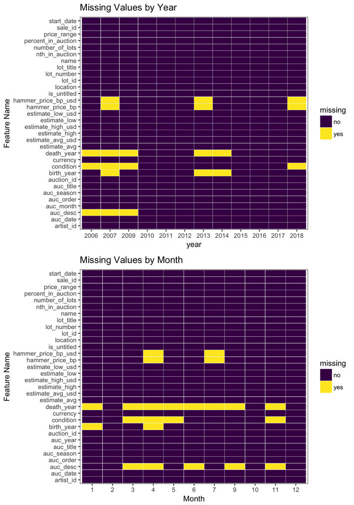

Next, let us look at the exact percentages and values for the overall missing data.

```r
#install.packages("skimr")
library(skimr)
skimr::skim(art_df) %>% filter(stat =="missing") %>% arrange(desc(value)) %>% select(variable, value) %>% mutate(percent = value/nrow(art_df)) %>% filter (percent>0)
```

```
## # A tibble: 14 x 3
##    variable              value  percent
##    <chr>                 <dbl>    <dbl>
##  1 death_year          14815   0.652
##  2 birth_year           5678   0.250
##  3 hammer_price_bp      3901   0.172
##  4 hammer_price_bp_usd  3901   0.172
##  5 auc_desc             3081   0.136
##  6 condition            2812   0.124
##  7 lot_title            2469   0.109
##  8 estimate_low           21.0 0.000925
##  9 estimate_high          21.0 0.000925
## 10 currency               21.0 0.000925
## 11 estimate_avg           21.0 0.000925
## 12 estimate_low_usd       21.0 0.000925
## 13 estimate_high_usd      21.0 0.000925
## 14 estimate_avg_usd       21.0 0.000925
```

Looking at the table, it actually appears that the estimates (along with its corresponding values generated during pre-processing) are only missing a very small amount of data (less than 1%). Therefore, such a small error can be easily filtered out in future analysis.

Nonetheless, hammer_price is missing nearly 20%. Besides what we saw when looking by location, our guess is that some auction ids are missing the hammer_price_bp in its entirety and hence the difference. It can be easily checked by looking at the aggregate table.

```r
art_price <- art_df[, c("auction_id", "hammer_price_bp")]
percent_missing <- art_price %>% group_by(auction_id) %>%
  summarise(num_na = sum(is.na(hammer_price_bp)), total = n()) %>%
  mutate(percent_na = num_na/total)%>%
  arrange(-percent_na)
percent_missing %>% filter(percent_na>=0.4)
```

```
## # A tibble: 10 x 4
##    auction_id num_na total percent_na
##         <int>  <int> <int>      <dbl>
##  1          2    258   258      1.00
##  2          3    173   173      1.00
##  3        108     48    90      0.533
##  4        180      8    16      0.500
##  5        100    116   240      0.483
##  6        186      7    15      0.467
##  7        133     47   103      0.456
##  8         30     36    81      0.444
##  9         20    136   335      0.406
## 10         19     14    35      0.400
```

Looking at the data table, there is a significant number of auctions that are missing more than 10% of the price data (sometimes even 100%). Therefore, it must be that not only the locations but also the auction itself is a determining factor in missing hammer price value.

Lastly, we would like to check for correlation between average hammer_price_bp and percentage of missing values (since it is the one feature that matters the most in our analysis and is most prime to such correlations). Could it be that very high/low lots are simply not reported and, therefore, are missing more?

```r
art_auction <- art_df[, c("auction_id", "hammer_price_bp")] %>% arrange(auction_id)
art_average <-art_auction %>% filter(!is.na(hammer_price_bp)) %>%
  group_by(auction_id) %>% summarise(mean =mean(hammer_price_bp)) %>% arrange(auction_id)
percent_missing <- percent_missing %>% arrange(auction_id)
add_2 <- data.frame(auction_id=2, mean=0)
add_3 <- data.frame(auction_id=3, mean=0)
art_average <- rbind(art_average, add_2)
art_average <- rbind(art_average, add_3) %>% arrange(auction_id)
percent <- percent_missing[4]
average <- art_average[2]
auction_id <- percent_missing[1]
corr <- data.frame(auction_id=auction_id, percent=percent, average = average)
ggplot(corr, aes(average, percent)) + geom_point(col="blue") +ggtitle("Auction Average Hammer Price vs Percentage of Missing Values")
```

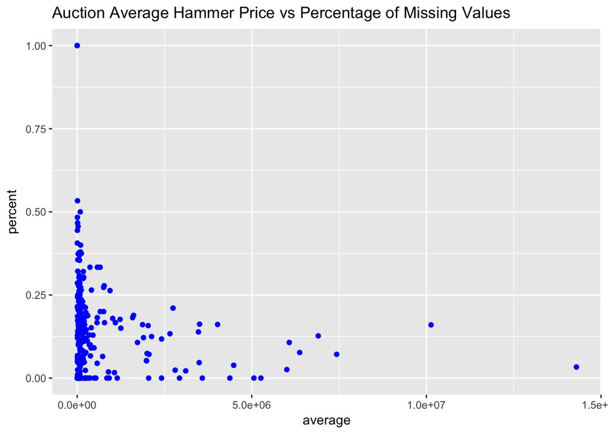

[figure not shown]

There does not seem to be very strong correlation between the two variables.Just a subtle suggestion that auctions with smaller average price tend to have more NAs. Therefore, we will only consider location as the main determinant for missing values around hammer_price_bp.

Before we move on, let us quickly follow up on the action items from the data quality analysis.

1. filter out NAs for price estimates
2. take a note to exclude Doha and Hong Kong fro hammer_price_bp analysis

```r
art_final <- art_df %>% filter(!is.na(estimate_low))
```

# Main Analysis (Exploratory Data Analysis)

## Financial Crisis and Auction Revenue

Let’s start by looking at the total revenue of Sothebeys on a yearly scale. Our guess is that we are supposed to see a significant drop around the time of the financial crisis.

```r
art_finance <- art_final[c("auc_year", "auc_month", "location","hammer_price_bp_usd")] %>% filter(!is.na(hammer_price_bp_usd))
art_yearfin <- art_finance %>% group_by(auc_year) %>% summarise(revenue = sum(hammer_price_bp_usd))
ggplot(art_yearfin, aes(x=auc_year, y=as.numeric(revenue/1000000))) +geom_line(col="blue")+ggtitle("Financial Crisis' Effect on Auction Revenue ($M)")+ylab("Revenue")+xlab("Year")
```

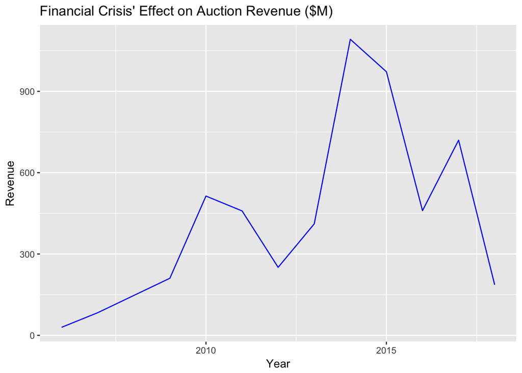

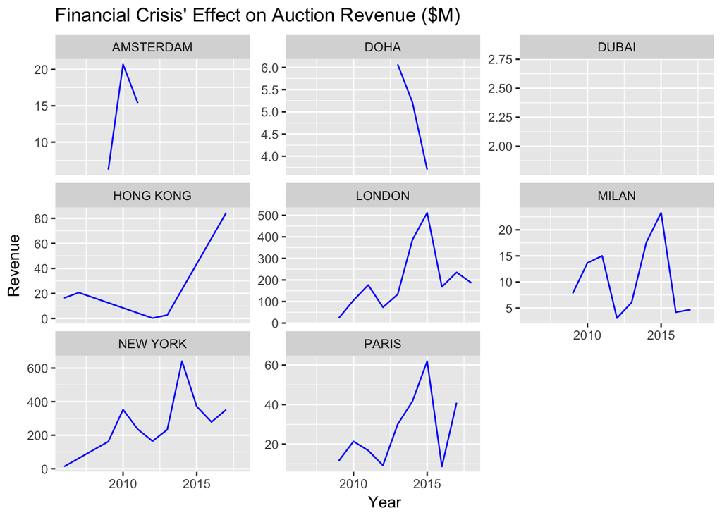

```r
art_locfin <- art_finance %>% group_by(auc_year, location) %>% summarise(revenue = sum(hammer_price_bp_usd))
ggplot(art_locfin, aes(x=auc_year, y=as.numeric(revenue/1000000))) +geom_line(col="blue")+ggtitle("Financial Crisis' Effect on Auction Revenue ($M)")+ylab("Revenue")+xlab("Year") + facet_wrap(~location, scales ="free_y")
```

It looks like, indeed, some locations do not have consistent data and might be throwing the calculation off (Dubai, Doha, and Amsterdam). Let us tke a look at the same chart without those locations.

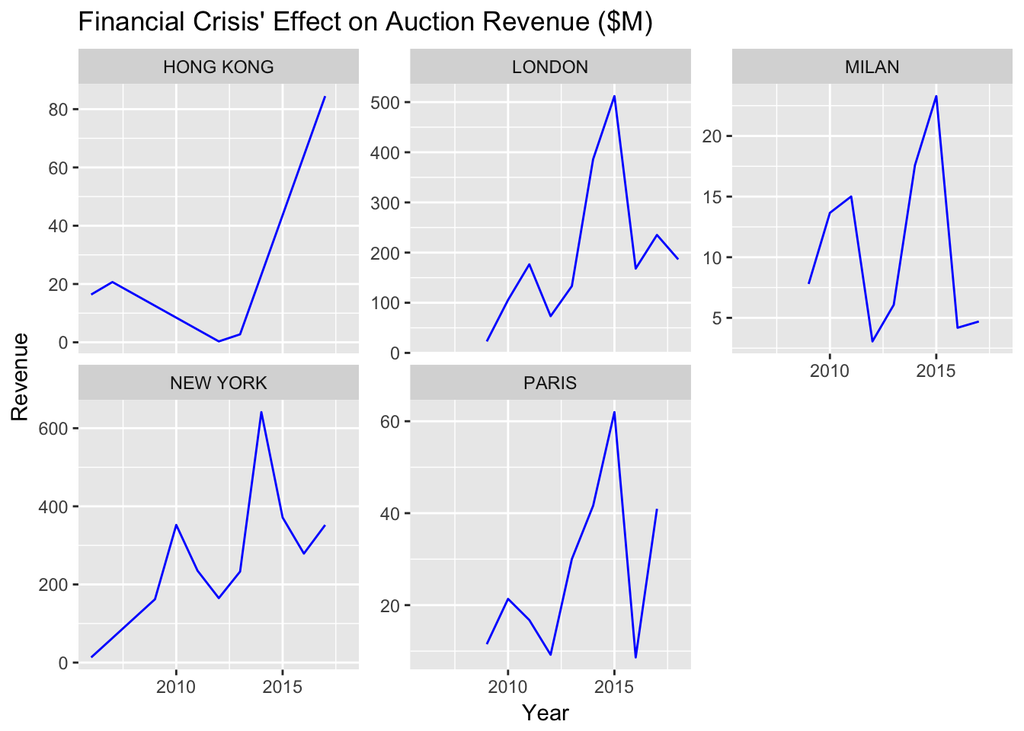

```r
art_locfin <- art_finance %>% group_by(auc_year, location) %>% summarise(revenue = sum(hammer_price_bp_usd)) %>% filter(location %in%  c("HONG KONG", "NEW YORK", "LONDON", "PARIS", "MILAN"))
ggplot(art_locfin, aes(x=auc_year, y=as.numeric(revenue/1000000))) +geom_line(col="blue")+ggtitle("Financial Crisis' Effect on Auction Revenue ($M)")+ylab("Revenue")+xlab("Year") + facet_wrap(~location, scales ="free_y")
```

[figure not shown]

[figure not shown]

```r
art_locfin <- art_finance %>% group_by(auc_year, location) %>% summarise(revenue = sum(hammer_price_bp_usd))
ggplot(art_locfin, aes(x=auc_year, y=as.numeric(revenue/1000000))) +geom_line(col="blue")+ggtitle("Financial Crisis' Effect on Auction Revenue ($M)")+ylab("Revenue")+xlab("Year") + facet_wrap(~location, scales ="free_y")
```

[figure not shown]

```r
art_locfin <- art_finance %>% group_by(auc_year, location) %>% summarise(revenue = sum(hammer_price_bp_usd)) %>% filter(location %in%  c("HONG KONG", "NEW YORK", "LONDON", "PARIS", "MILAN"))
ggplot(art_locfin, aes(x=auc_year, y=as.numeric(revenue/1000000))) +geom_line(col="blue")+ggtitle("Financial Crisis' Effect on Auction Revenue ($M)")+ylab("Revenue")+xlab("Year") + facet_wrap(~location, scales ="free_y")
```